# Airline Pilot Retention Analysis

Author

Michael J. Hickey

Published

November 11, 2025

Why Records Were Excluded

| exclusion_reason | n |
| --- | --- |
| did_not_finish | 35 |
| included | 76 |
| not_air_carrier | 2 |

```
**Total records in file:** 113 \n\n**Records kept for analysis:** 76 \n\n**Records excluded:** 37
```

```r
write_csv(included_data, here("data/processed/retention_cleaned.csv"))
```

# Statistical Methods

## Multiple Testing Correction

FDR at q=0.10 means we accept that approximately 10% of significant findings may be false positives, while ensuring we identify 90% of true demographic differences. This error balance is appropriate when findings prompt further research rather than immediate policy decisions.

**Within-Subjects Testing:** Friedman test assesses whether the six retention factors differ in importance. Post-hoc pairwise comparisons use Wilcoxon signed-rank tests with Holm’s sequentially rejective procedure. Holm is used rather than BH-FDR because repeated-measures comparisons are strongly dependent (same participants in all comparisons), and BH-FDR could inflate false positive rates under such dependence. Holm maintains family-wise error rate control for dependent tests while being more powerful than Bonferroni.

**Small Sample Adjustments:** Gender comparisons use exact Mann-Whitney U tests (rather than asymptotic approximations) due to small female subsample (n=8). Exact tests provide valid inference with samples below n=10 where asymptotic assumptions fail. Exact tests require the coin package for computation.

**References:** Benjamini & Hochberg (1995); Bender & Lange (1999); Armstrong (2014).

Descriptive Statistics for Age

| n | min_age | q1_age | median_age | mean_age | q3_age | max_age | sd_age | iqr_age | skew_age | kurt_age |
| --- | --- | --- | --- | --- | --- | --- | --- | --- | --- | --- |
| 76 | 21 | 26 | 29 | 32.41 | 35 | 63 | 9.91 | 9 | 1.46 | 1.48 |

```
Shapiro–Wilk normality test p‑value: 0
```

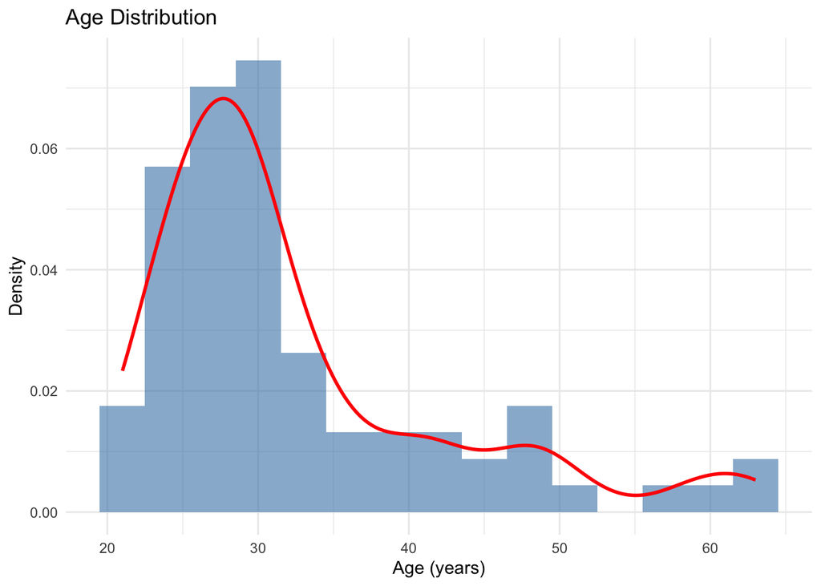

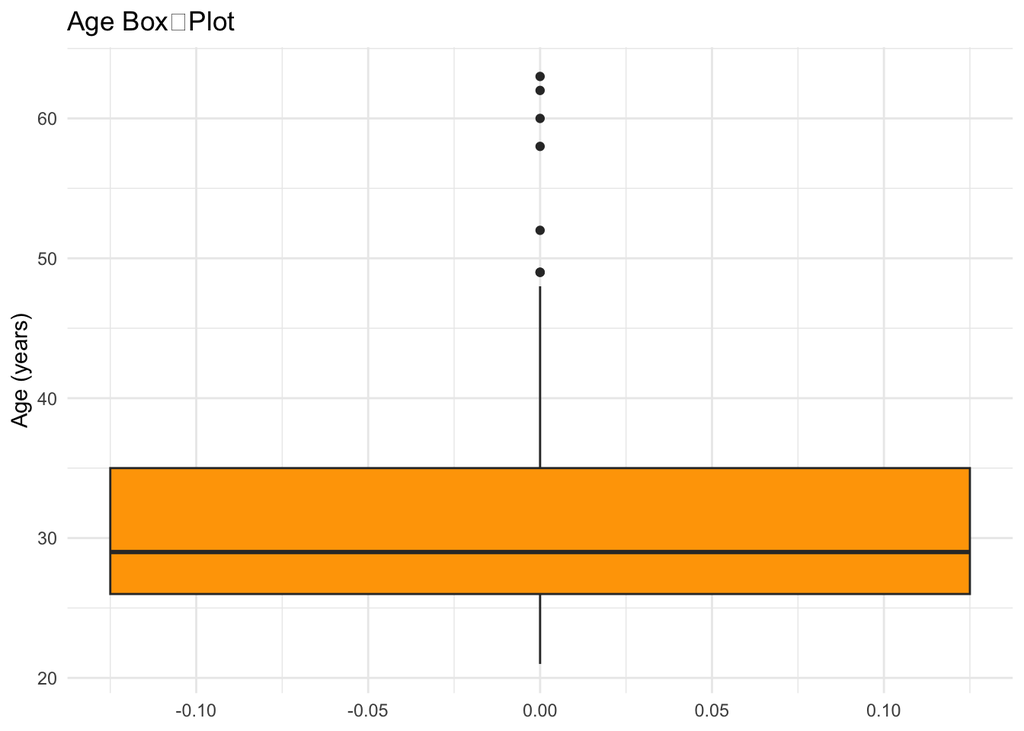

Age Distribution: ≤ 35 vs > 35

| Age Group | n | % |
| --- | --- | --- |
| ≤ 35 | 58 | 76.3 |
| > 35 | 18 | 23.7 |

Descriptive Statistics for Years of Experience

| n | min_exp | q1_exp | median_exp | mean_exp | q3_exp | max_exp | sd_exp | iqr_exp | skew_exp | kurt_exp |
| --- | --- | --- | --- | --- | --- | --- | --- | --- | --- | --- |
| 76 | 1 | 2 | 3 | 5.78 | 7 | 30 | 6.55 | 5 | 2.21 | 4.74 |

```
Shapiro–Wilk normality test p‑value: 3.131e-11
```

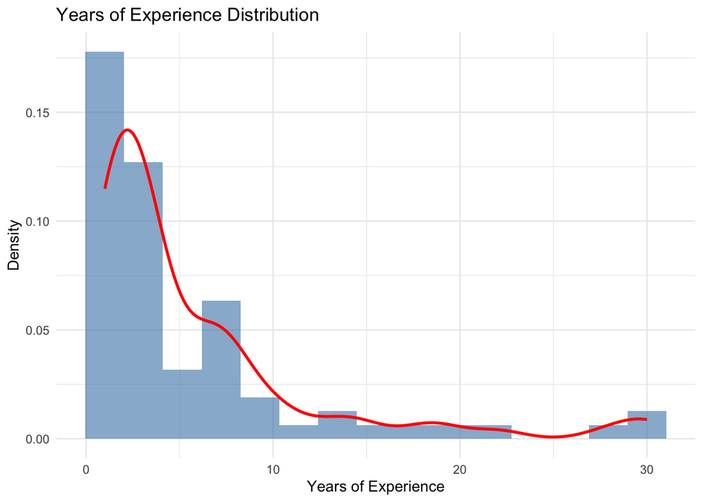

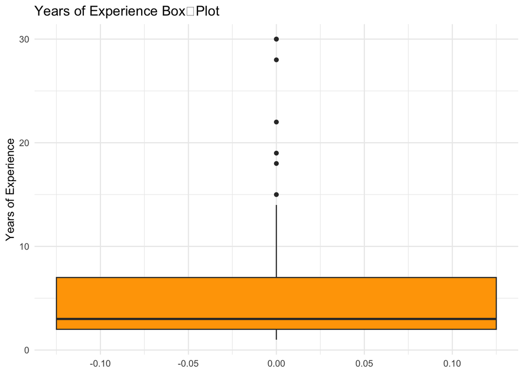

Descriptive Statistics for Total Flying Hours

| n | min_hours | q1_hours | median_hours | mean_hours | q3_hours | max_hours | sd_hours | iqr_hours | skew_hours | kurt_hours |
| --- | --- | --- | --- | --- | --- | --- | --- | --- | --- | --- |
| 76 | 840 | 2015 | 2900 | 4532.13 | 4500 | 22000 | 4490.88 | 2485 | 2.41 | 5.48 |

```
Shapiro–Wilk normality test p‑value: 3.991e-12
```

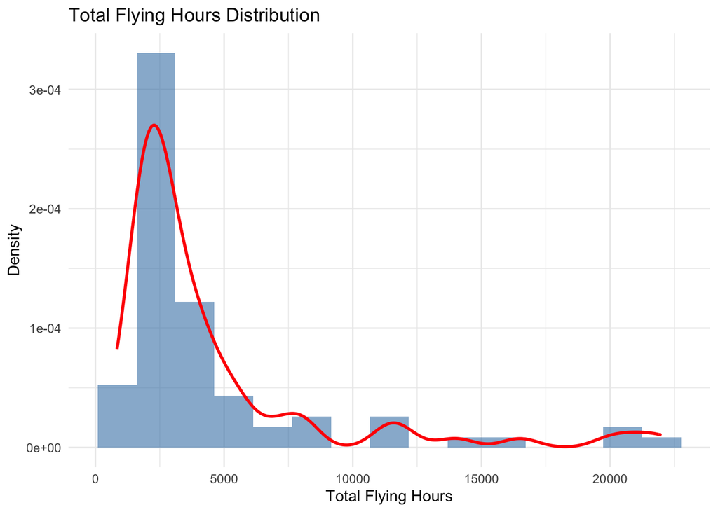

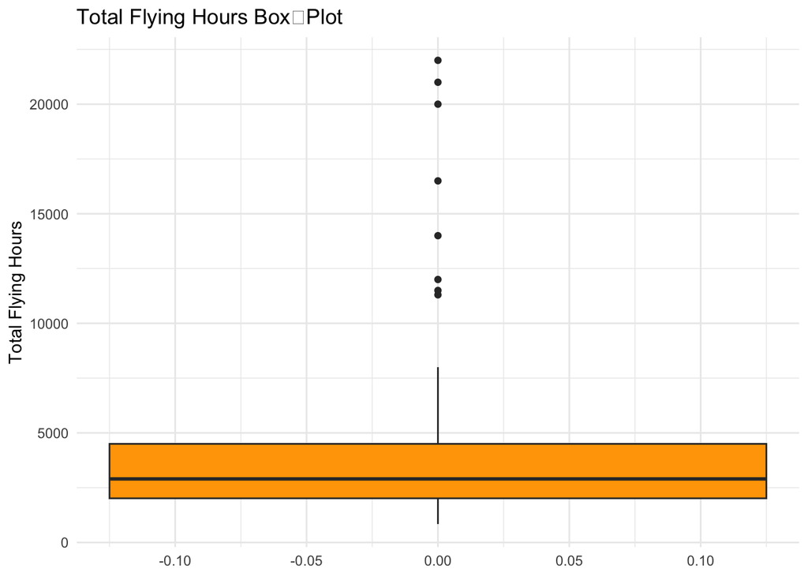

Gender Distribution

| gender | n | percent |
| --- | --- | --- |
| Female | 8 | 10.5% |
| Male | 67 | 88.2% |
| Prefer not to say | 1 | 1.3% |
| Total | 76 | 100.0% |

```
Missing / blank gender responses: 0
```

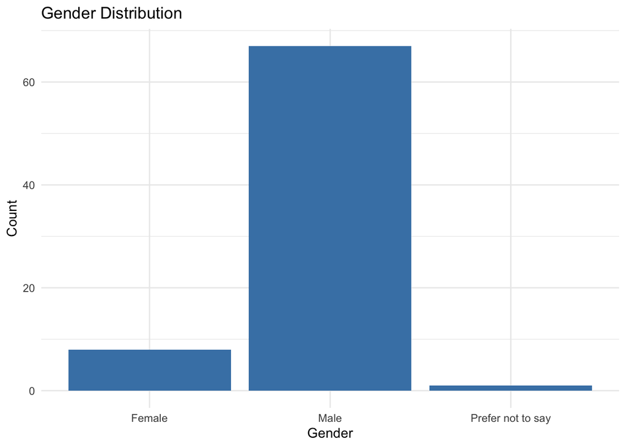

Air‑Carrier Type Distribution

| air_carrier_type | n | percent |
| --- | --- | --- |
| Charter/Fractional (Part 135/91K) | 2 | 2.6% |
| Freight/Cargo Carrier | 1 | 1.3% |
| Legacy/Mainline Part 121 Airline | 11 | 14.5% |
| Low Cost Carrier | 5 | 6.6% |
| Regional Airline | 57 | 75.0% |
| Total | 76 | 100.0% |

```
Missing / blank carrier‑type responses: 0
```

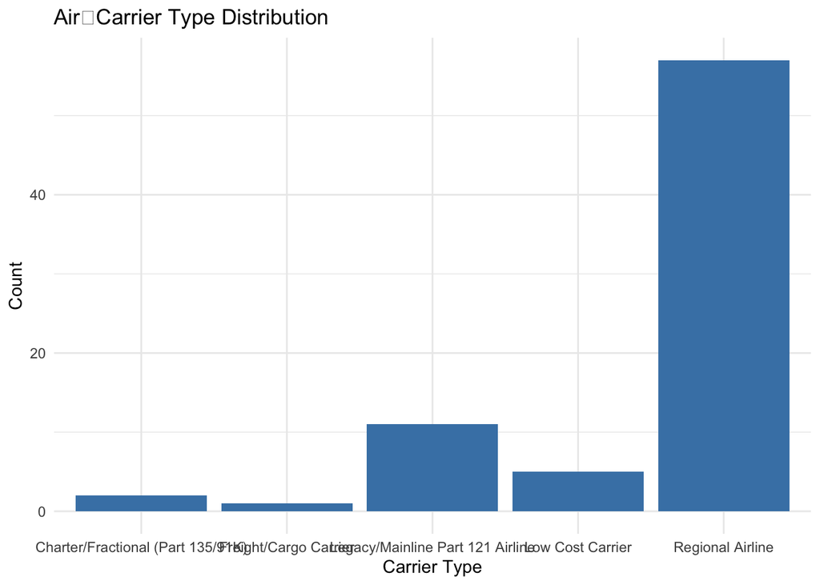

Flight‑Deck Position Distribution

| position_position | n | percent |
| --- | --- | --- |
| Captain | 26 | 34.2% |
| First Officer | 50 | 65.8% |
| Total | 76 | 100.0% |

```
Missing / blank position responses: 0
```

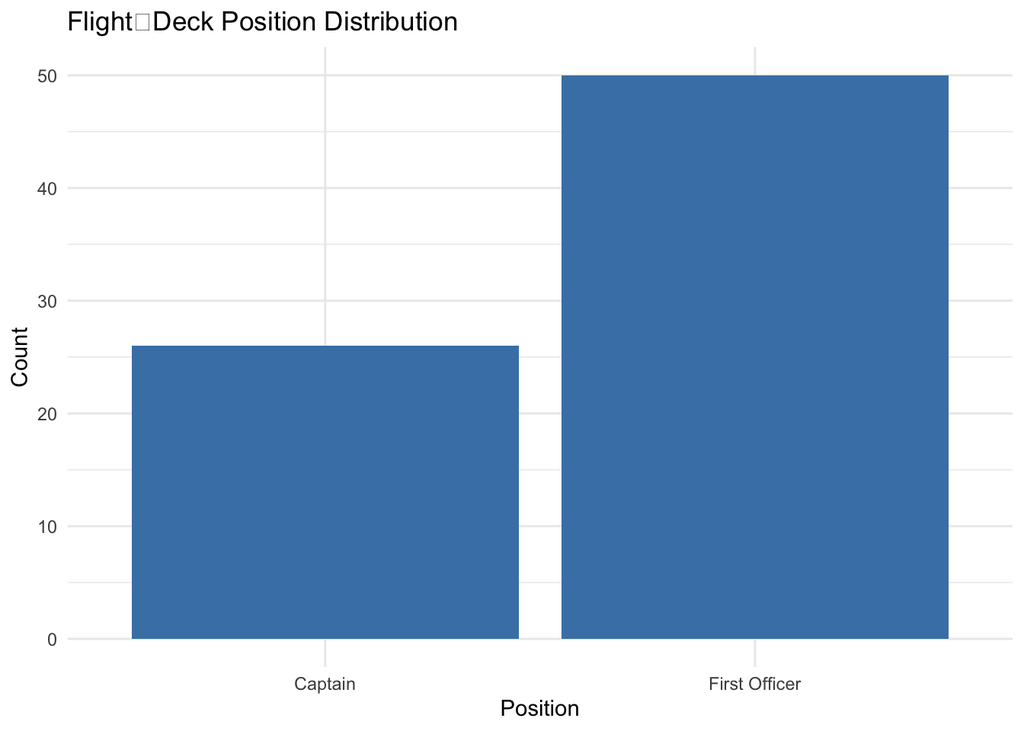

Military Experience Distribution (Yes / No)

| military_bg | n | percent |
| --- | --- | --- |
| No | 69 | 90.8% |
| Yes | 7 | 9.2% |
| Total | 76 | 100.0% |

```
Missing military‑experience responses: 0
```

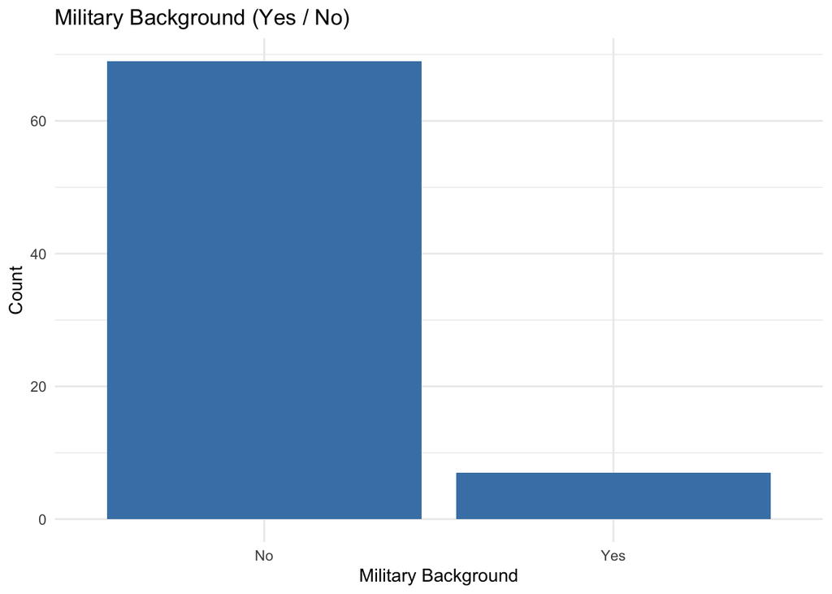

Nationality – Full Country Breakdown

| nationality | n | percent |
| --- | --- | --- |
| United States of America | 70 | 92.1% |
| Ethiopia | 1 | 1.3% |
| Germany | 1 | 1.3% |
| India | 1 | 1.3% |
| Lao People’s Democratic Republic | 1 | 1.3% |
| Mexico | 1 | 1.3% |
| New Zealand | 1 | 1.3% |

Nationality Re‑coded to US vs Foreign

| us_vs_foreign | n | percent |
| --- | --- | --- |
| Foreign | 6 | 7.9% |
| US | 70 | 92.1% |
| Total | 76 | 100.0% |

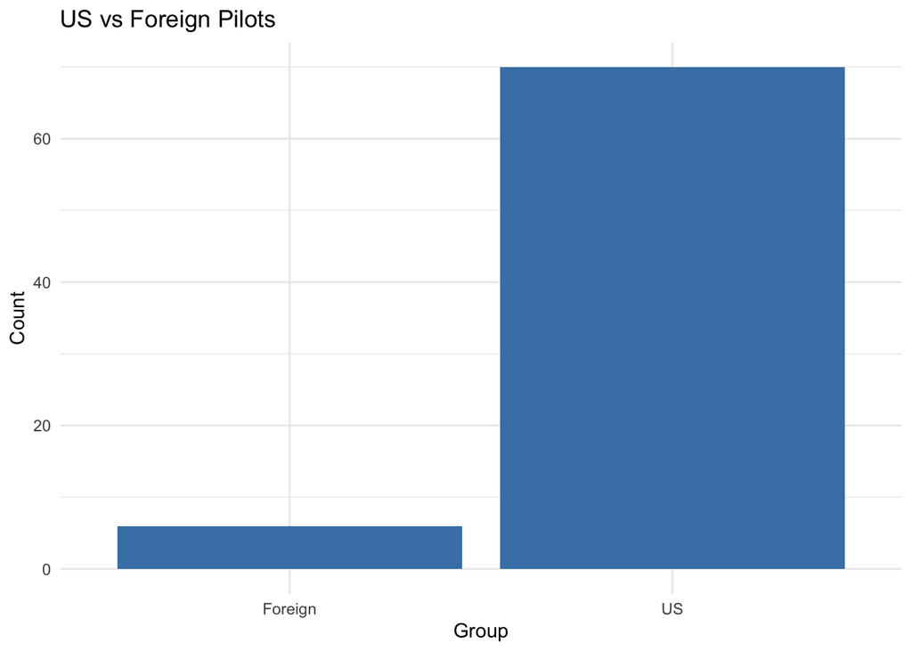

### –RESEARCH QUESTION ANALYSES–

Table 1 Rank Summary for General Retention Factors

| factor | n | median | iqr |
| --- | --- | --- | --- |
| financial | 76 | NA | 2 |
| lifestyle | 76 | NA | 2 |
| operational | 76 | NA | 1 |
| professional | 76 | NA | 1 |
| recognition | 76 | NA | 1 |
| schedule | 76 | NA | 1 |

Table 2 Number (and %) of Pilots Ranking Each Factor #1

| factor | n | percent |
| --- | --- | --- |
| lifestyle | 34 | 44.7 |
| financial | 25 | 32.9 |
| schedule | 13 | 17.1 |
| professional | 3 | 3.9 |
| operational | 1 | 1.3 |

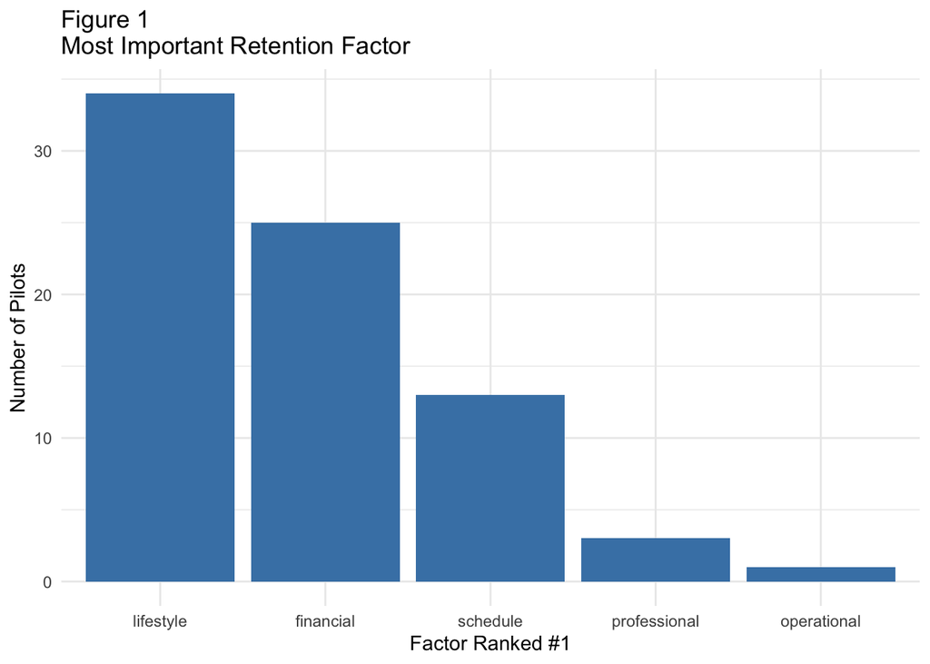

```
# A tibble: 1 × 6
  .y.       n statistic    df        p method
* <chr> <int>     <dbl> <dbl>    <dbl> <chr>
1 rank     76      234.     5 1.27e-48 Friedman test
```

Table 3 Pairwise Wilcoxon Tests Between General Factors (Holm‑adjusted p‑values)

| comparison | p.sig |
| --- | --- |
| financial vs lifestyle | 0.426 |
| financial vs operational | < .001 |
| financial vs professional | < .001 |
| financial vs recognition | < .001 |
| financial vs schedule | 0.426 |
| lifestyle vs operational | < .001 |
| lifestyle vs professional | < .001 |
| lifestyle vs recognition | < .001 |
| lifestyle vs schedule | 0.062 |
| operational vs professional | 0.892 |
| operational vs recognition | < .001 |
| operational vs schedule | < .001 |
| professional vs recognition | < .001 |
| professional vs schedule | < .001 |
| recognition vs schedule | < .001 |

Table 4 Mann‑Whitney U Tests: Age Groups (≤ 35 vs > 35) on General‑Factor Ranks

| Factor | n ≤35 | Median ≤35 | n >35 | Median >35 | Statistic | p (raw) | p (FDR) | Sig (q=0.10) | n1 | n2 |
| --- | --- | --- | --- | --- | --- | --- | --- | --- | --- | --- |
| lifestyle | 58 | 1 | 18 | 2.5 | 726.0 | 0.008 | 0.049 | TRUE | 18 | 58 |
| financial | 58 | 2 | 18 | 2.0 | 436.0 | 0.276 | 0.736 | FALSE | 18 | 58 |
| schedule | 58 | 2 | 18 | 2.0 | 466.0 | 0.477 | 0.736 | FALSE | 18 | 58 |
| professional | 58 | 5 | 18 | 4.0 | 479.0 | 0.584 | 0.736 | FALSE | 18 | 58 |
| recognition | 58 | 6 | 18 | 6.0 | 488.5 | 0.613 | 0.736 | FALSE | 18 | 58 |
| operational | 58 | 4 | 18 | 4.0 | 505.0 | 0.832 | 0.832 | FALSE | 18 | 58 |

Table 5 Median Rank of General Factors by Experience Quartile

| factor | Q1 (least)_n | Q2_n | Q3_n | Q4 (most)_n | Q1 (least)_median | Q2_median | Q3_median | Q4 (most)_median |
| --- | --- | --- | --- | --- | --- | --- | --- | --- |
| financial | 19 | 19 | 19 | 19 | 2 | 2 | 2 | 2 |
| lifestyle | 19 | 19 | 19 | 19 | 1 | 2 | 2 | 2 |
| operational | 19 | 19 | 19 | 19 | 5 | 4 | 4 | 4 |
| professional | 19 | 19 | 19 | 19 | 4 | 5 | 5 | 5 |
| recognition | 19 | 19 | 19 | 19 | 6 | 6 | 6 | 6 |
| schedule | 19 | 19 | 19 | 19 | 3 | 2 | 2 | 2 |

Table 6 Kruskal–Wallis Tests for Experience Quartiles (FDR‑adjusted p)

| Factor | Statistic | df | p (raw) | p (FDR) | Sig (q=0.10) |
| --- | --- | --- | --- | --- | --- |
| financial | 0.551 | 3 | 0.908 | 0.908 | FALSE |
| lifestyle | 3.854 | 3 | 0.278 | 0.834 | FALSE |
| operational | 1.364 | 3 | 0.714 | 0.908 | FALSE |
| professional | 1.015 | 3 | 0.798 | 0.908 | FALSE |
| recognition | 4.639 | 3 | 0.200 | 0.834 | FALSE |
| schedule | 2.619 | 3 | 0.454 | 0.908 | FALSE |

```
Gender counts:
```

```
Female   Male   <NA>
     8     67      1
```

Table 7 Median Rank of General Factors by Gender

| factor | Female_n | Male_n | Female_median | Male_median |
| --- | --- | --- | --- | --- |
| financial | 8 | 67 | 3 | 2 |
| lifestyle | 8 | 67 | 1 | 2 |
| operational | 8 | 67 | 4 | 5 |
| professional | 8 | 67 | 5 | 5 |
| recognition | 8 | 67 | 6 | 6 |
| schedule | 8 | 67 | 2 | 2 |

Table 8 Mann‑Whitney U Tests: Male vs Female (Exact test; FDR‑adjusted p)

| Factor | Statistic | p (raw) | p (FDR) | Sig (q=0.10) | n1 | n2 |
| --- | --- | --- | --- | --- | --- | --- |
| financial | 365 | 0.084 | 0.168 | FALSE | 8 | 67 |
| lifestyle | 212 | 0.312 | 0.353 | FALSE | 8 | 67 |
| operational | 157 | 0.047 | 0.168 | FALSE | 8 | 67 |
| professional | 320 | 0.353 | 0.353 | FALSE | 8 | 67 |
| recognition | 356 | 0.061 | 0.168 | FALSE | 8 | 67 |
| schedule | 192 | 0.174 | 0.261 | FALSE | 8 | 67 |

```
Military background counts:
```

```
Yes  No
  7  69
```

Table 9 Median Rank of General Factors by Military Background

| factor | Yes_n | No_n | Yes_median | No_median |
| --- | --- | --- | --- | --- |
| financial | 7 | 69 | 2 | 2 |
| lifestyle | 7 | 69 | 2 | 2 |
| operational | 7 | 69 | 5 | 4 |
| professional | 7 | 69 | 4 | 5 |
| recognition | 7 | 69 | 6 | 6 |
| schedule | 7 | 69 | 2 | 2 |

Table 10 Mann‑Whitney U Tests: Military vs Civilian (FDR‑adjusted p)

| Factor | Statistic | p (raw) | p (FDR) | Sig (q=0.10) | n1 | n2 |
| --- | --- | --- | --- | --- | --- | --- |
| financial | 262.5 | 0.701 | 0.841 | FALSE | 7 | 69 |
| lifestyle | 231.5 | 0.856 | 0.856 | FALSE | 7 | 69 |
| operational | 271.5 | 0.578 | 0.841 | FALSE | 7 | 69 |
| professional | 205.5 | 0.502 | 0.841 | FALSE | 7 | 69 |
| recognition | 284.5 | 0.338 | 0.841 | FALSE | 7 | 69 |
| schedule | 198.5 | 0.423 | 0.841 | FALSE | 7 | 69 |

```
Carrier group counts:
```

```
     LCC    Major    Other Regional
       5       11        3       57
```

Table 11 Median Rank of General Factors by Carrier Group

| factor | LCC_n | Major_n | Other_n | Regional_n | LCC_median | Major_median | Other_median | Regional_median |
| --- | --- | --- | --- | --- | --- | --- | --- | --- |
| financial | 5 | 11 | 3 | 57 | 3 | 2 | 1 | 2 |
| lifestyle | 5 | 11 | 3 | 57 | 2 | 1 | 2 | 2 |
| operational | 5 | 11 | 3 | 57 | 4 | 4 | 4 | 4 |
| professional | 5 | 11 | 3 | 57 | 5 | 5 | 4 | 5 |
| recognition | 5 | 11 | 3 | 57 | 6 | 6 | 6 | 6 |
| schedule | 5 | 11 | 3 | 57 | 1 | 3 | 3 | 2 |

Table 12 Kruskal–Wallis Tests Across Carrier Groups (FDR‑adjusted p)

| Factor | Statistic | df | p (raw) | p (FDR) | Sig (q=0.10) |
| --- | --- | --- | --- | --- | --- |
| financial | 5.451 | 3 | 0.142 | 0.426 | FALSE |
| lifestyle | 1.479 | 3 | 0.687 | 0.687 | FALSE |
| operational | 2.792 | 3 | 0.425 | 0.661 | FALSE |
| professional | 2.304 | 3 | 0.512 | 0.661 | FALSE |
| recognition | 2.102 | 3 | 0.551 | 0.661 | FALSE |
| schedule | 9.233 | 3 | 0.026 | 0.158 | FALSE |

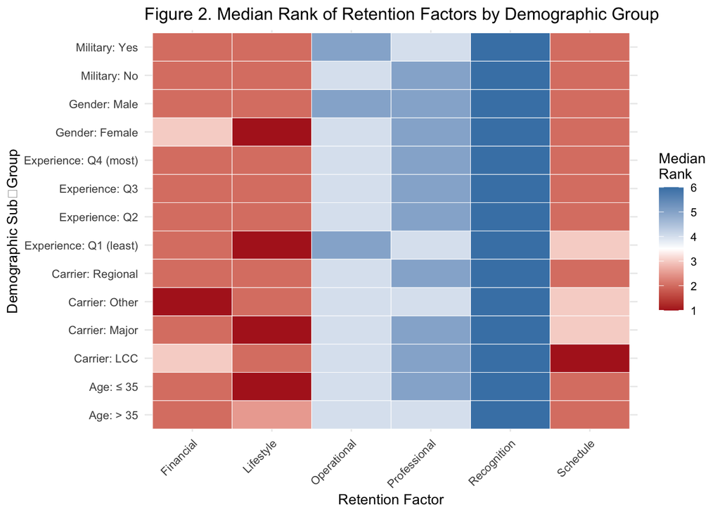

# Results Summary

Summary of BH-FDR Results Across Demographic Comparisons

[output not shown]

```
Position counts:
```

```
      Captain First Officer
           26            50
```

Table X1 Median Rank of General Factors by Flight‑Deck Position

| factor | Captain_n | First Officer_n | Captain_median | First Officer_median |
| --- | --- | --- | --- | --- |
| financial | 26 | 50 | 2 | 2 |
| lifestyle | 26 | 50 | 2 | 2 |
| operational | 26 | 50 | 5 | 4 |
| professional | 26 | 50 | 4 | 5 |
| recognition | 26 | 50 | 6 | 6 |
| schedule | 26 | 50 | 2 | 2 |

Table X2 Mann‑Whitney U Tests: Captain vs First Officer (FDR‑adjusted p)

| Factor | Statistic | p (raw) | p (FDR) | Sig (q=0.10) | n1 | n2 |
| --- | --- | --- | --- | --- | --- | --- |
| financial | 489.0 | 0.067 | 0.200 | FALSE | 26 | 50 |
| lifestyle | 723.0 | 0.398 | 0.478 | FALSE | 26 | 50 |
| operational | 865.0 | 0.014 | 0.082 | TRUE | 26 | 50 |
| professional | 543.0 | 0.219 | 0.438 | FALSE | 26 | 50 |
| recognition | 573.5 | 0.296 | 0.444 | FALSE | 26 | 50 |
| schedule | 669.0 | 0.832 | 0.832 | FALSE | 26 | 50 |

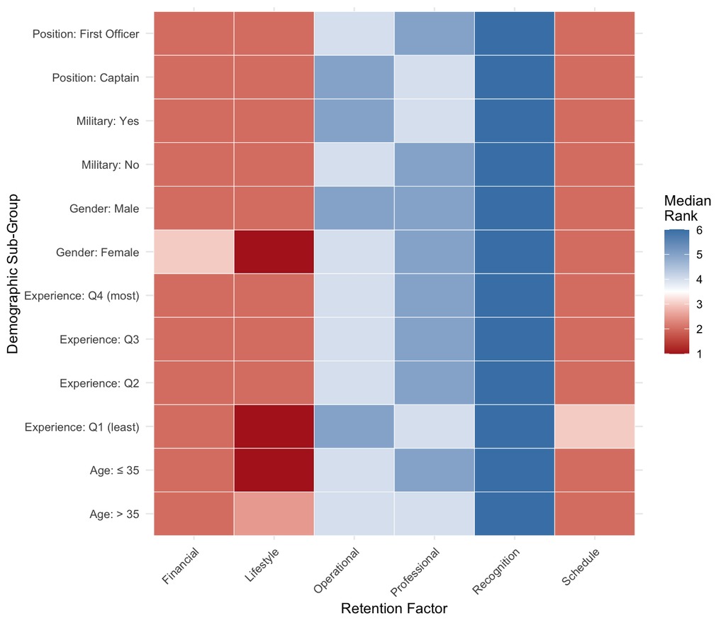